# Amazon Product Review Analysis

###### back to Top

#### Summary by categories

- The categories were **not well balanced** among themselves. Electronics has the most products, reviews and revewers.
- **Electronics,Media** has the highest quality reviews with better `reviews.numHelpful` and `reviews.len`

```python
res = data.groupby('primaryCategories')\
    .agg(num_product = pd.NamedAgg('name', pd.Series.nunique),
         num_reviewer = pd.NamedAgg('reviews.username', pd.Series.nunique),
         num_review = pd.NamedAgg('reviews.text', pd.Series.nunique),
         avg_review_len = pd.NamedAgg('reviews.len', lambda i: np.round(np.mean(i),2)),
         avg_rating = pd.NamedAgg('reviews.rating', lambda i: np.round(np.mean(i),2)),
         avg_review_helpful = pd.NamedAgg('reviews.numHelpful', lambda i: np.round(np.mean(i),2))
          )
res
```

| primaryCategories | num_product | num_reviewer | num_review | avg_review_len | avg_rating | avg_review_helpful |
| --- | --- | --- | --- | --- | --- | --- |
| Electronics | 18 | 2535 | 2827 | 158.39 | 4.55 | 0.37 |
| Electronics,Hardware | 2 | 1233 | 1341 | 163.43 | 4.70 | 0.13 |
| Electronics,Media | 1 | 24 | 24 | 521.21 | 4.67 | 2.96 |
| Office Supplies,Electronics | 2 | 227 | 236 | 154.05 | 4.62 | 0.40 |

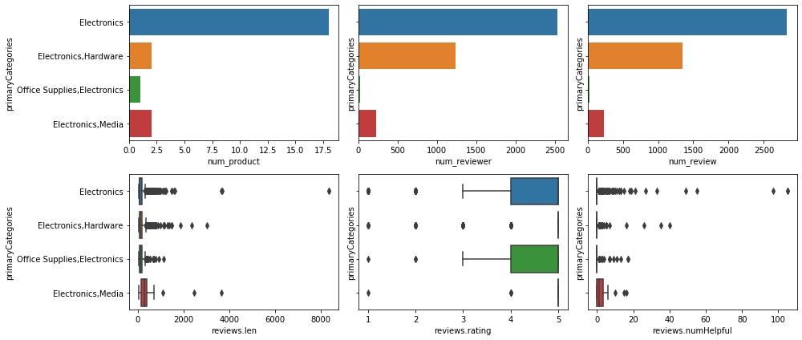

```python
fig, axs = plt.subplots(2,3, sharey=True)
fig.set_size_inches(14, 6)
sns.barplot(res['num_product'],  res.index, ax = axs[0,0])
sns.barplot(res['num_reviewer'], res.index, ax = axs[0,1])
sns.barplot(res['num_review'],   res.index, ax = axs[0,2])
sns.boxplot(data['reviews.len'], data.primaryCategories, ax=axs[1,0])
sns.boxplot(data['reviews.rating'], data.primaryCategories, ax=axs[1,1])
sns.boxplot(data['reviews.numHelpful'], data.primaryCategories, ax=axs[1,2])
plt.tight_layout()
plt.show()
```

###### back to Top

#### summary by year-month

We have seen a peak of number of reviews on 2017-03 over 12 different products. This may be due to some bias in data collection and not necessarily reflect the real distribution of the reviews.

```python
res = data.groupby('ym')\
    .agg(num_product = pd.NamedAgg('name', pd.Series.nunique),
           num_review = pd.NamedAgg('reviews.text', pd.Series.nunique),
           avg_review_len = pd.NamedAgg('reviews.len', lambda i: np.round(np.mean(i),2)),
           avg_rating = pd.NamedAgg('reviews.rating', lambda i: np.round(np.mean(i),2))
          ).reset_index()
res
```

|  | ym | num_product | num_review | avg_review_len | avg_rating |
| --- | --- | --- | --- | --- | --- |
| 0 | 2015-12 | 2 | 43 | 155.34 | 4.84 |
| 1 | 2016-03 | 1 | 82 | 232.80 | 4.65 |
| 2 | 2016-04 | 1 | 371 | 140.05 | 4.46 |
| 3 | 2016-06 | 1 | 418 | 129.26 | 4.51 |
| 4 | 2016-08 | 1 | 96 | 156.11 | 4.67 |
| 5 | 2017-01 | 2 | 781 | 156.87 | 4.56 |
| 6 | 2017-03 | 12 | 1524 | 172.30 | 4.57 |
| 7 | 2017-11 | 1 | 4 | 89.25 | 5.00 |
| 8 | 2018-02 | 1 | 648 | 180.63 | 4.67 |
| 9 | 2018-04 | 1 | 195 | 184.67 | 4.65 |
| 10 | 2018-05 | 1 | 590 | 137.47 | 4.75 |

###### back to Top

#### Correlations

There is some mild correlation between `reviews.len` and `reveiews.numHelpful`, which may suggest that longer reviews tend to be more helpful for other users.

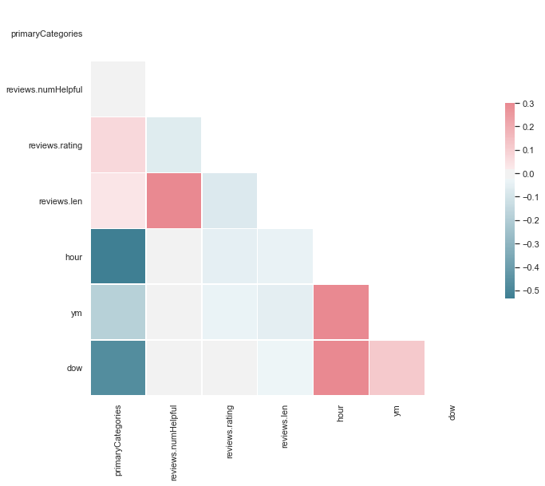

```python
from string import ascii_letters
import numpy as np
import pandas as pd
import seaborn as sns
import matplotlib.pyplot as plt
sns.set(style="white")

# convert categorical columns to integers to estimate their correlations
fnames_categorical = ['hour','dow','ym','primaryCategories']
data_ = data.copy()
data_[fnames_categorical] = data_[fnames_categorical].apply(lambda i: pd.factorize(i)[0])
corr = data_.corr()

# Generate a mask for the upper triangle
mask = np.triu(np.ones_like(corr, dtype=np.bool))

# Set up the matplotlib figure
f, ax = plt.subplots(figsize=(11, 9))

# Generate a custom diverging colormap
cmap = sns.diverging_palette(220, 10, as_cmap=True)

# Draw the heatmap with the mask and correct aspect ratio
sns.heatmap(corr, mask=mask, cmap=cmap, vmax=.3, center=0,
            square=True, linewidths=.5, cbar_kws={"shrink": .5})
```

Because of the sparsity of the data, there are a lot reviews with zero `numHelpful`, which makes it difficult to view the pattern of the correlation. After removing zero cout of `numHelpful`, we are able to find a correlation between review length and number helpful recieved.

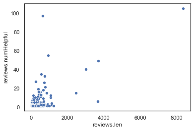

```python
sns.scatterplot('reviews.len', 'reviews.numHelpful', data = data.query('`reviews.numHelpful` > 0'))
```

###### back to Top

## Text analysis

Just take some random reviews to take a look.

```python
# check some random reviews
random_reviews = data.sample(3)

for i in range(len(random_reviews)):
    print('Review #{} ({} stars) {}'.format(i,
                                               random_reviews['reviews.rating'].iloc[i],
                                               random_reviews['dateAdded'].iloc[i]))
    print(random_reviews['reviews.title'].iloc[i])
    print(random_reviews['reviews.text'].iloc[i])
    print('-'* 50 + '\r')
```

[output not shown]

### Tokenization

Tokenization means breaking sentences into words / phrases.

Following is an example of tokenziation using any character other than alphanum.

```python
# Tokenize the documents.
from nltk.tokenize import RegexpTokenizer

# Split the documents into tokens.
tokenizer = RegexpTokenizer(r'\w+')

def process_text(x):
    x = x.lower()
    return tokenizer.tokenize(x)

raw_text = random_reviews['reviews.text'].iloc[0]

print('-'* 60)
print('raw review: \n' + raw_text)
print('-'* 60)
print('tokenized review: \n' + str(process_text(raw_text)))
print('-'* 60)
```

```
------------------------------------------------------------
raw review:
Our 5th Echo Show. We love the Drop In feature, allowing us to use them as an intercom. The ease of playing music on all of them at once throughout the house, and controlled from any device is used daily. The connection to our Sonos system is a real plus. Also connected to our Dish TV receiver.
------------------------------------------------------------
tokenized review:
['our', '5th', 'echo', 'show', 'we', 'love', 'the', 'drop', 'in', 'feature', 'allowing', 'us', 'to', 'use', 'them', 'as', 'an', 'intercom', 'the', 'ease', 'of', 'playing', 'music', 'on', 'all', 'of', 'them', 'at', 'once', 'throughout', 'the', 'house', 'and', 'controlled', 'from', 'any', 'device', 'i…
------------------------------------------------------------
```

###### back to Top

### World cloud by category

word cloud is an another interesting visualization to show the distribution of tokens of text.

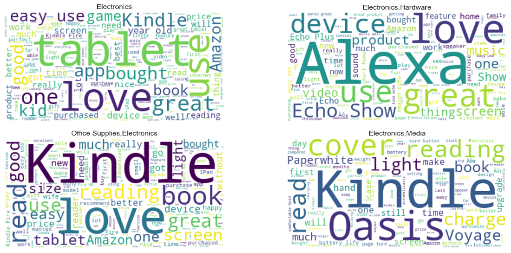

```python
from wordcloud import WordCloud
fig, axs = plt.subplots(2,2)
fig.set_size_inches(14,6)
for i, cate in enumerate(data.primaryCategories.unique()):
    text = '\n'.join(data.loc[data.primaryCategories == cate, 'reviews.text'].values)
    wordcloud = WordCloud(background_color='white').generate(text)
    axs[i // 2, i % 2].imshow(wordcloud, interpolation="bilinear")
    axs[i // 2, i % 2].set_title(cate)
    axs[i // 2, i % 2].axis('off')
fig.tight_layout()
plt.show()
```

###### back to Top

## Sentiment Analysis

Sentiment Analysis is to score the sentiment from the human text. It can be used to monitor the brand awareness/perceptions, customer's attitude towards products via analyzing the reveiews.

**How does sentiment score work ?**

In a sentiment model, it stores lists of postive / neutral / negative keywords and compare the tokens with the keywords to compute the individual pos/neu/neg scores. Finally a combined score will be aggegrated as the sentiment score for the sentence.

Following is an example of sentiment analysis of a random review.

- neg: negative score
- neu: neutral score
- pos: positive score
- compound: combined score

```python
analyzer = SentimentIntensityAnalyzer()
text = random_reviews['reviews.text'].iloc[0]
print(text)
analyzer.polarity_scores(text)
```

```
Our 5th Echo Show. We love the Drop In feature, allowing us to use them as an intercom. The ease of playing music on all of them at once throughout the house, and controlled from any device is used daily. The connection to our Sonos system is a real plus. Also connected to our Dish TV receiver.
```

```
{'neg': 0.033, 'neu': 0.833, 'pos': 0.134, 'compound': 0.7506}
```

```python
pos_reviews = data.loc[data['reviews.rating'] == 5, :].sample(2)
neg_reviews = data.loc[data['reviews.rating'] == 1, :].sample(2)
random_reviews = pd.concat([pos_reviews, neg_reviews])
scores = random_reviews['reviews.text'].map(lambda i: analyzer.polarity_scores(i)['compound'])
random_reviews['score'] = scores
```

Show some more examples of Positive & Negative sentiment reviews

```python
for i in range(len(random_reviews)):
    print('Review #{} ({} stars) by {}'.format(i,
                                               random_reviews['reviews.rating'].iloc[i],
                                               random_reviews['reviews.username'].iloc[i]))
    print(random_reviews['reviews.title'].iloc[i])
    print('{} (sentiment score: {:0.2f})'.format(random_reviews['reviews.text'].iloc[i],
                                               random_reviews['score'].iloc[i]))
    print('-'*50 + '\r')
```

```
Review #0 (5 stars) by dm94101
awesome
I was looking everywhere for this because I lost my charger for my fire stick and i finally found it at best buy. It was a great price and works perfectly! (sentiment score: 0.88)
--------------------------------------------------
Review #1 (5 stars) by LPark
Excellent tablet for the low price
The amazon fire tablet 2016 is quite good. It provides sufficient content & ability to do all of the basics one requires in a tablet. The 8 inch screen is bright and provides various settings. The tablet's light weight makes it very portable. (sentiment score: 0.77)
--------------------------------------------------
Review #2 (1 stars) by JohnS
terrible product,bad voice quality
the speaker voice quality is terrible compare the similar size my logitech UE BOOM.the price is too high, even I got on promotion with $79 (sentiment score: -0.48)
--------------------------------------------------
Review #3 (1 stars) by joesedita
Amazon Fire 7 Tablet
Too bad Amazon turned this tablet into a big advertising tool. Many apps dont work and the camera is not good. (sentiment score: -0.64)
--------------------------------------------------
```

I correlated the sentiment score with review ratings as a method of validation. Generally speaking, the sentiment score is well correlated with review ratings. This is also making sense that, angry customer are making negative reveiws and gave the rating as low as possible.

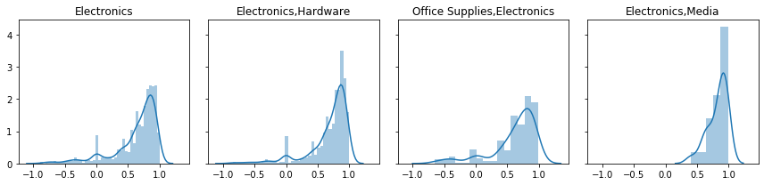

```python
scores = data['reviews.text'].map(lambda i: analyzer.polarity_scores(i)['compound'])
data['score'] = scores

# sentiment score distribution

fig, axs = plt.subplots(ncols=4, sharey=True, sharex=True)
fig.set_size_inches(12, 3)
for idx, cate in enumerate(data.primaryCategories.unique()):
    sns.distplot(data.loc[data.primaryCategories == cate, 'score'].values, ax = axs[idx])
    axs[idx].set_title(cate)
fig.tight_layout()
plt.show()
```

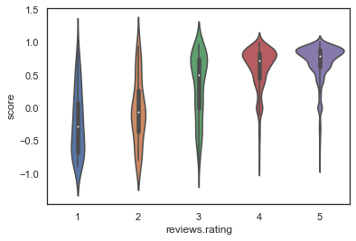

```python
# relationship between score and rating
sns.violinplot(x='reviews.rating', y='score', data=data)
```

###### back to Top

## Topic Modelling

Topic modelling clusters the corpus of texts into several topics(groups) by assuming:

- A document/review is mix distribution of different topics
- A topic is mix distributino of different tokens(words)

Topic modelling helps us to understand proximity of the review meanings. In the following section, I cluster the reviews into 5 topics, and an interactive visualization was generate to explore how each topic was made up with different words, so that we can use our domain knowledge to come up with a specific topic tag for those reviews.

In some modern e-commerce site (Taobao), topic tags were added at the top of the review section for customer to quickly filter review with certrain types of topics

```python
# Tokenize the documents.
from nltk.tokenize import RegexpTokenizer

# Split the documents into tokens.
tokenizer = RegexpTokenizer(r'\w+')

def process_text(x):
    x = x.lower()
    return tokenizer.tokenize(x)

docs = data['reviews.text'].map(process_text)

# Remove numbers, but not words that contain numbers.
docs = [[token for token in doc if not token.isnumeric()] for doc in docs]

# Remove words that are only one character.
docs = [[token for token in doc if len(token) > 1] for doc in docs]

# Remove stopwords
from nltk.corpus import stopwords
docs = [[token for token in doc if token not in stopwords.words('english')] for doc in docs]
```

```python
# Lemmatize the documents.
from nltk.stem.wordnet import WordNetLemmatizer

lemmatizer = WordNetLemmatizer()
docs = [[lemmatizer.lemmatize(token) for token in doc] for doc in docs]

# Compute bigrams.
from gensim.models import Phrases

# Add bigrams and trigrams to docs (only ones that appear 20 times or more).
bigram = Phrases(docs, min_count=20)
for idx in range(len(docs)):
    for token in bigram[docs[idx]]:
        if '_' in token:
            # Token is a bigram, add to document.
            docs[idx].append(token)

# Remove rare and common tokens.
from gensim.corpora import Dictionary

# Create a dictionary representation of the documents.
dictionary = Dictionary(docs)

# Filter out words that occur less than 20 documents, or more than 50% of the documents.
dictionary.filter_extremes(no_below=20, no_above=0.5)

# Bag-of-words representation of the documents.
corpus = [dictionary.doc2bow(doc) for doc in docs]

print('Number of unique tokens: %d' % len(dictionary))
print('Number of documents: %d' % len(corpus))
```

```
Number of unique tokens: 670
Number of documents: 5000
```

```python
# Train LDA model.
from gensim.models import LdaModel

# Set training parameters.
num_topics = 5
chunksize = 2000
passes = 20
iterations = 200
eval_every = None  # Don't evaluate model perplexity, takes too much time.

# Make a index to word dictionary.
temp = dictionary[0]  # This is only to "load" the dictionary.
id2word = dictionary.id2token

model = LdaModel(
    corpus=corpus,
    id2word=id2word,
    chunksize=chunksize,
    alpha='auto',
    eta='auto',
    iterations=iterations,
    num_topics=num_topics,
    passes=passes,
    eval_every=eval_every
)

top_topics = model.top_topics(corpus) #, num_words=20)

# Average topic coherence is the sum of topic coherences of all topics, divided by the number of topics.
avg_topic_coherence = sum([t[1] for t in top_topics]) / num_topics
print('Average topic coherence: %.4f.' % avg_topic_coherence)
```

```
Average topic coherence: -2.4597.
```

```python
import pyLDAvis.gensim
pyLDAvis.enable_notebook()
vis = pyLDAvis.gensim.prepare(model, corpus, dictionary)
vis
```

[interactive chart not shown]

###### back to Top